# Global GAM

Ryan Hankins

# Prepare Data

```r
c = c( "logchla", "Regions", "Date","Year", "Month",  "season","SAC","lagSAC",
       "EXPORT","OUT","lagOUT", "SJR", "lagSJR", "Index","lagIndex","DissAmmonia",
       "lagDissAmmonia", "TotPhos","lagTotPhos","DissNitrateNitrite",
       "lagDissNitrateNitrite","Temperature","lagTemperature","Secchi",
       "lagSecchi","Conductivity",  "lagConductivity","season_num")#, #"Biomass","Grazing_rate",#"Filtration_rate")


df <- read.csv("Data/regional_integrated_dataset3.csv" )

df$Date = as.Date(df$Date)

# 1979 is the start of the study period.
df <- subset(df,df$Date >= "1979-01-01")


# Changing Regions to factor for GAM to work as a random effect.
df$Regions = as.factor(df$Regions)

# Changing season to numeric value for cyclic cubic spline
df$season_num = as.numeric(as.factor(df$season))

# log transforming chl-a to achieve normal distribution of response variable.
df$logchla <- log(df$Chlorophyll)

# other option is using na.exclude on gams
# Dropping NAs from the dataset.
df <- subset(df, select = c)%>%
   drop_na()

# z-score standardizing the dataset for more logical comparison of predictors. This facilitates comparison of effect sizes between variables.

df <- df %>% mutate(across(!c(Regions,season,Date,Month, Year, season_num), ~as.vector(scale(.))))

df
```

| logchla | Regions | Date | Year | Month | season | SAC | lagSAC | EXPORT | OUT | lagOUT | SJR | lagSJR | Index | lagIndex | DissAmmonia | lagDissAmmonia | TotPhos | lagTotPhos | DissNitrateNitrite | lagDissNitrateNitrite | Temperature | lagTemperature | Secchi | lagSecchi | Conductivity | lagConductivity | season_num |
| --- | --- | --- | --- | --- | --- | --- | --- | --- | --- | --- | --- | --- | --- | --- | --- | --- | --- | --- | --- | --- | --- | --- | --- | --- | --- | --- | --- |
| 2.199707e-01 | Central | 1979-11-01 | 1979 | 11 | Autumn | -0.469646732 | -0.488928597 | -0.24331780 | -0.365485513 | -0.628116188 | -0.3610037472 | -0.509364369 | 0.31165547 | -0.46595805 | -0.2941862621 | -0.832308511 | 0.329874837 | 0.284357485 | 0.0780704441 | -0.6019711523 | -0.760931631 | 1.710526223 | -0.250220484 | -0.924647743 | -0.4481425315 | -0.409025986 | 1 |
| 3.296829e-01 | Central | 1979-12-01 | 1979 | 12 | Autumn | -0.173803278 | -0.488928597 | -0.20604976 | -0.195098756 | -0.628116188 | -0.3357524155 | -0.509364369 | 0.31165547 | -0.46595805 | -0.3665956182 | -0.832308511 | 0.626651650 | 0.284357485 | -0.1497331390 | -0.6019711523 | -1.033300760 | 1.710526223 | -0.539312627 | -0.924647743 | -0.4515045180 | -0.409025986 | 1 |
| 3.445949e-01 | Central | 1981-11-01 | 1981 | 11 | Autumn | 0.555495267 | -0.568334354 | -0.60797884 | 0.226664614 | -0.632342743 | -0.4754699387 | -0.559237572 | 1.53117601 | -0.61457689 | 1.1829646035 | -0.869873795 | 0.788529911 | 0.462608086 | 0.5897523385 | -0.6695133979 | -0.112816911 | 1.584680739 | -0.004391082 | -0.570372779 | -0.3914114488 | -0.417512536 | 1 |
| -5.965841e-01 | Central | 1981-12-01 | 1981 | 12 | Autumn | 2.238243639 | -0.568334354 | -0.46414981 | 1.476314643 | -0.632342743 | -0.4320200650 | -0.559237572 | 1.53117601 | -0.61457689 | 0.8933271789 | -0.869873795 | 0.977387883 | 0.462608086 | 0.8315746036 | -0.6695133979 | -1.046919216 | 1.584680739 | -0.522157708 | -0.570372779 | -0.4420112493 | -0.417512536 | 1 |
| 8.240123e-02 | Central | 1983-10-01 | 1983 | 10 | Autumn | -0.125894161 | 0.240944634 | -1.31558473 | 0.134271709 | 0.193457525 | 1.3049003576 | 1.407391335 | 0.62637045 | 2.31902963 | -0.6272693004 | -0.700830017 | -0.371597629 | -0.349422431 | -0.3915554041 | -0.4355228486 | 0.456217910 | 1.492213227 | -0.437018484 | -0.876367452 | -0.4862688885 | -0.495259736 | 1 |
| -4.089535e-01 | Central | 1983-12-01 | 1983 | 12 | Autumn | 2.957998887 | 0.240944634 | -1.43208177 | 3.173588557 | 0.193457525 | 2.1835685541 | 1.407391335 | 0.62637045 | 2.31902963 | -0.1493675498 | -0.700830017 | -0.074820817 | -0.349422431 | 0.1656872069 | -0.4355228486 | -1.169485324 | 1.492213227 | -0.370304913 | -0.876367452 | -0.4742873410 | -0.495259736 | 1 |
| -6.313104e-02 | Central | 1983-11-01 | 1983 | 11 | Autumn | 1.473226394 | 0.240944634 | -1.55620420 | 1.174375190 | 0.193457525 | 0.9345133030 | 1.407391335 | 0.62637045 | 2.31902963 | -0.3376318758 | -0.700830017 | -0.317638209 | -0.349422431 | 0.0114817044 | -0.4355228486 | -0.211937608 | 1.492213227 | -0.389207091 | -0.876367452 | -0.4630568757 | -0.495259736 | 1 |
| -9.582687e-01 | Central | 1985-12-01 | 1985 | 12 | Autumn | -0.417263613 | -0.595862637 | 1.03731487 | -0.433623136 | -0.659934591 | -0.3783915114 | -0.372974134 | 0.61325733 | -0.53057494 | 0.8933271789 | -0.815233382 | 1.139266144 | -0.250394319 | 0.4495655181 | -0.2582072589 | -1.033300760 | 1.538280152 | 0.061109515 | -0.184155295 | -0.3295788606 | -0.417757613 | 1 |
| 8.190669e-01 | Central | 1985-11-01 | 1985 | 11 | Autumn | -0.746013981 | -0.595862637 | 0.22825073 | -0.496754779 | -0.659934591 | -0.4202051769 | -0.372974134 | 0.61325733 | -0.53057494 | -0.6475439201 | -0.815233382 | 0.146412807 | -0.250394319 | -0.5976300301 | -0.2582072589 | -1.067346901 | 1.538280152 | 0.634846228 | -0.184155295 | -0.3270037221 | -0.417757613 | 1 |
| 6.630445e-01 | Central | 1986-10-01 | 1986 | 10 | Autumn | -0.455479056 | -0.414294249 | 0.30975806 | -0.404342875 | -0.537645194 | -0.1458057442 | -0.200447383 | -0.73083789 | 0.59698968 | -0.6417511716 | -0.789620689 | -0.290658499 | 0.306638810 | -0.2128172082 | -0.1703060472 | 0.376209478 | 1.529432719 | -0.654949484 | -0.994310017 | -0.4552241626 | -0.450737390 | 1 |

[output cut: 1938 more lines]

# Model Selection

## Choose Models With Best Combination of Flow Variables

```r
options(na.action = "na.fail")

# OUT (no EXPORT, no step)
# m1 <- gam((logchla) ~ DissAmmonia +
#                DissNitrateNitrite +
#                Temperature +
#                Conductivity +
#                OUT +
#                s(Regions, bs='re') +
#                season +
#                (OUT*season) +
#                Grazing_rate +
#                lagOUT +
#                lagDissAmmonia +
#                lagDissNitrateNitrite,
#              data = df,
#              method = 'ML'
#              )
#
# # # SAC (no EXPORT, no step)
# m2 <- gam((logchla) ~ DissAmmonia +
#                DissNitrateNitrite +
#                Temperature +
#                Conductivity +
#                SAC +
#                s(Regions, bs='re') +
#                season +
#                (SAC*season) +
#                Grazing_rate +
#                lagSAC +
#                lagDissAmmonia +
#                lagDissNitrateNitrite,
#              data = df,
#              method = 'ML'
#              )
```

Replacing clam variables with a step function (pre/post potamocorbula introduction to the Bay in 1987)

```r
# Create dataframe with pre/post clam dummy variable
df=df%>%mutate(clam_step=if_else(Year>1987, "post clam", "pre clam"))
```

```r
# OUT + Step (no EXPORT)
m3 <- gam((logchla) ~ DissAmmonia +
               DissNitrateNitrite +
               Temperature +
               Conductivity +
               OUT +
               s(Regions, bs='re') +
               season +
               (OUT*season) +
            #replace grazing rate with clam step function
               clam_step +
               lagOUT +
               lagDissAmmonia +
               lagDissNitrateNitrite,
             data = df,
             method = 'ML'
             )

# SAC + Step (no EXPORT)
m4 <- gam((logchla) ~ DissAmmonia +
               DissNitrateNitrite +
               Temperature +
               Conductivity +
               SAC +
               s(Regions, bs='re') +
               season +
               (SAC*season) +
               clam_step +
               lagSAC +
               lagDissAmmonia +
               lagDissNitrateNitrite,
             data = df,
             method = 'ML'
             )

# OUT + EXPORT + Step
# m5 <- gam((logchla) ~ DissAmmonia +
#                DissNitrateNitrite +
#                Temperature +
#                Conductivity +
#                OUT +
#                EXPORT +
#                s(Regions, bs='re') +
#                season +
#                (OUT*season) +
#             #replace grazing rate with clam step function
#                clam_step +
#                lagOUT +
#                lagDissAmmonia +
#                lagDissNitrateNitrite,
#              data = df,
#              method = 'ML'
#              )

#SAC+ EXPORT + Step (best performing combo)
m6 <- gam((logchla) ~ DissAmmonia +
               DissNitrateNitrite +
               Temperature +
               Conductivity +
               SAC +
               EXPORT +
               s(Regions, bs='re') +
               season +
               (SAC*season) +
            #replace grazing rate with clam step function
               clam_step +
               lagSAC +
               lagDissAmmonia +
               lagDissNitrateNitrite,
             data = df,
             method = 'ML'
             )

# m6 but with Season as a numeric smooth term with bs=cc (cyclic cubic spline)
# m7 <- gam((logchla) ~ DissAmmonia +
#                DissNitrateNitrite +
#                Temperature +
#                Conductivity +
#                SAC +
#                EXPORT +
#                s(Regions, bs='re') +
#                s(season_num, bs='cc', k=4) +
#                (SAC*season) +
#             #replace grazing rate with clam step function
#                clam_step +
#                lagSAC +
#                lagDissAmmonia +
#                lagDissNitrateNitrite,
#              data = df,
#              method = 'ML'
#              )
# SJR + OUT + EXPORT
# m8 <- gam((logchla) ~ DissAmmonia +
#                DissNitrateNitrite +
#                Temperature +
#                Conductivity +
#                SJR +
#                EXPORT +
#                s(Regions, bs='re') +
#                s(season_num, bs='cc', k=4) +
#                (SJR*season) +
#             #replace grazing rate with clam step function
#                clam_step +
#                lagSJR +
#                lagDissAmmonia +
#                lagDissNitrateNitrite,
#              data = df,
#              method = 'ML'
#              )
# SJR + OUT (no EXPORT)
# m9 <- gam((logchla) ~ DissAmmonia +
#                DissNitrateNitrite +
#                Temperature +
#                Conductivity +
#                SJR +
#                s(Regions, bs='re') +
#                s(season_num, bs='cc', k=4) +
#                (SJR*season) +
#             #replace grazing rate with clam step function
#                clam_step +
#                lagSJR +
#                lagDissAmmonia +
#                lagDissNitrateNitrite,
#              data = df,
#              method = 'ML'
#              )
```

## Compare with AIC

```r
AIC(m3, m4,m6)
```

|  | df | AIC |
| --- | --- | --- |
| m3 | 20.99955 | 4140.205 |
| m4 | 20.99955 | 4140.749 |
| m6 | 21.99955 | 4136.427 |

```r
BIC(m3, m4, m6)
```

|  | df | BIC |
| --- | --- | --- |
| m3 | 20.99955 | 4257.268 |
| m4 | 20.99955 | 4257.812 |
| m6 | 21.99955 | 4259.065 |

## Decisions/observations:

- Best combo of flow variables is OUT without EXPORT (m3)
  - This is different than before the data was z-scored, when the best performing model was m6
- remove month random effect
- keep season, try cyclic cubic spline bs=“cc”, set k=4 (m7)
- add region as a random effect
- models performed better with clam data as a step function

# Reduce variables in top models:

Dredging the top models to determine which variables to remove.

## m1

```r
# OUT (no EXPORT, no step)
# df <- subset(df, select = c)%>%
#    drop_na()
#options(na.action = "na.fail")
#m.1.dredge <- dredge(m1)
#m.1.dredge
```

## m2

```r
# # SAC (no EXPORT, no step)
# m.2.dredge <- dredge(m2)
# head(m.2.dredge, 3)
```

## m.3 - active

```r
# OUT + Step (no EXPORT)
m.3.dredge <- dredge(m3)
head(m.3.dredge, 3)
```

|  | (Intercept) | clam_step | Conductivity | DissAmmonia | DissNitrateNitrite | lagDissAmmonia | lagDissNitrateNitrite | lagOUT | OUT | s(Regions, bs = "re") | season | Temperature | OUT:season | df | logLik | AICc | delta | weight |
| --- | --- | --- | --- | --- | --- | --- | --- | --- | --- | --- | --- | --- | --- | --- | --- | --- | --- | --- |
| 4032 | -0.2304139 | + | -0.07862417 | -0.03694689 | 0.08625717 | 0.1263168 | -0.03850642 | NA | -0.1067602 | + | + | 0.3472265 | + | 19 | -2049.220 | 4138.875 | 0.00000000 | 0.3923486 |
| 4000 | -0.2253008 | + | -0.08308883 | -0.03505069 | 0.07705438 | 0.1199832 | NA | NA | -0.1074056 | + | + | 0.3452428 | + | 18 | -2050.265 | 4138.918 | 0.04269182 | 0.3840623 |
| 3996 | -0.2297848 | + | -0.08394627 | NA | 0.06865171 | 0.1105455 | NA | NA | -0.1019153 | + | + | 0.3534027 | + | 17 | -2051.826 | 4140.000 | 1.12468098 | 0.2235891 |

## m.4 - active

```r
# SAC + Step (no EXPORT)
m.4.dredge <- dredge(m4)
head(m.4.dredge, 3)
```

|  | (Intercept) | clam_step | Conductivity | DissAmmonia | DissNitrateNitrite | lagDissAmmonia | lagDissNitrateNitrite | lagSAC | s(Regions, bs = "re") | SAC | season | Temperature | SAC:season | df | logLik | AICc | delta | weight |
| --- | --- | --- | --- | --- | --- | --- | --- | --- | --- | --- | --- | --- | --- | --- | --- | --- | --- | --- |
| 4000 | -0.2131782 | + | -0.08560294 | -0.03835522 | 0.07272937 | 0.1258119 | NA | NA | + | -0.06543533 | + | 0.3384380 | + | 18 | -2050.280 | 4138.947 | 0.000000 | 0.3805596 |
| 4032 | -0.2174376 | + | -0.08166712 | -0.03998895 | 0.08111103 | 0.1314288 | -0.03450866 | NA | + | -0.06429987 | + | 0.3403883 | + | 19 | -2049.426 | 4139.288 | 0.340772 | 0.3209408 |
| 1984 | -0.2333214 | + | -0.08246506 | -0.03998555 | 0.08103062 | 0.1279275 | -0.04189203 | NA | + | -0.08123626 | + | 0.3204127 | NA | 16 | -2052.558 | 4139.433 | 0.485748 | 0.2984996 |

## m5

```r
# OUT + EXPORT + Step
#m.5.dredge <- dredge(m5)
#m.5.dredge
```

## m.6 -active

```r
# SAC+ EXPORT + Step (best performing combo)
m.6.dredge <- dredge(m6)
head(m.6.dredge, 3)
```

|  | (Intercept) | clam_step | Conductivity | DissAmmonia | DissNitrateNitrite | EXPORT | lagDissAmmonia | lagDissNitrateNitrite | lagSAC | s(Regions, bs = "re") | SAC | season | Temperature | SAC:season | df | logLik | AICc | delta | weight |
| --- | --- | --- | --- | --- | --- | --- | --- | --- | --- | --- | --- | --- | --- | --- | --- | --- | --- | --- | --- |
| 4032 | -0.2055420 | + | -0.08466978 | -0.03389011 | 0.07757472 | -0.05007744 | 0.1304598 | NA | 0.05050478 | + | -0.08860726 | + | 0.3192069 | NA | 17 | -2049.216 | 4134.780 | 0.0000000 | 0.3848226 |
| 8000 | -0.2104449 | + | -0.08861456 | -0.03367053 | 0.07455767 | -0.04685436 | 0.1292093 | NA | NA | + | -0.06038723 | + | 0.3366285 | + | 19 | -2047.371 | 4135.171 | 0.3912706 | 0.3164442 |
| 4096 | -0.2116618 | + | -0.08148396 | -0.03538307 | 0.08519092 | -0.04975055 | 0.1353620 | -0.03286116 | 0.04543980 | + | -0.08704750 | + | 0.3212773 | NA | 18 | -2048.446 | 4135.286 | 0.5064631 | 0.2987332 |

## m7

```r
# m6 but with as a numeric smooth term with bs=cc (cyclic cubic spline)
# m.7.dredge <- dredge(m7)
# head(m.7.dredge, 3)
```

## m8

```r
# SJR+EXPORT+ Step
# m.8.dredge <- dredge(m8)
# head(m.7.dredge, 3)
```

# Compare top models with AIC/BIC

```r
#top.m1 <- get.models(m.1.dredge, 1)[[1]]
#top.m2 <- get.models(m.2.dredge, 1)[[1]]
top.m3 <- get.models(m.3.dredge, 1)[[1]]
top.m4 <- get.models(m.4.dredge, 1)[[1]]
#top.m5 <- get.models(m.5.dredge, 1)[[1]]
top.m6 <- get.models(m.6.dredge, 1)[[1]]
#top.m7 <- get.models(m.7.dredge, 1)[[1]]
#top.m8 <- get.models(m.8.dredge, 1)[[1]]
```

compare the top dredged models with AIC and BIC

```r
AIC(top.m3, top.m4, top.m6)
```

|  | df | AIC |
| --- | --- | --- |
| top.m3 | 19.99956 | 4138.439 |
| top.m4 | 18.99644 | 4138.553 |
| top.m6 | 17.99641 | 4134.425 |

```r
BIC(top.m3, top.m4, top.m6)
```

|  | df | BIC |
| --- | --- | --- |
| top.m3 | 19.99956 | 4249.928 |
| top.m4 | 18.99644 | 4244.450 |
| top.m6 | 17.99641 | 4234.747 |

# Remove Season

The interaction with Sac:season was not significant in m6 but was in m3 and m4

```r
# OUT + Step (no EXPORT)
m3.no.season <- gam((logchla) ~ DissAmmonia +
               DissNitrateNitrite +
               Temperature +
               Conductivity +
               OUT +
               s(Regions, bs='re') +
            #replace grazing rate with clam step function
               clam_step +
               lagOUT +
               lagDissAmmonia +
               lagDissNitrateNitrite,
             data = df,
             method = 'ML'
             )

# SAC + Step (no EXPORT)
m4.no.season <- gam((logchla) ~ DissAmmonia +
               DissNitrateNitrite +
               Temperature +
               Conductivity +
               SAC +
               s(Regions, bs='re') +
               clam_step +
               lagSAC +
               lagDissAmmonia +
               lagDissNitrateNitrite,
             data = df,
             method = 'ML'
             )

#SAC+ EXPORT + Step (best performing combo)
m6.no.season <- gam((logchla) ~ DissAmmonia +
               DissNitrateNitrite +
               Temperature +
               Conductivity +
               SAC +
               EXPORT +
               s(Regions, bs='re') +
            #replace grazing rate with clam step function
               clam_step +
               lagSAC +
               lagDissAmmonia +
               lagDissNitrateNitrite,
             data = df,
             method = 'ML'
             )
```

## m3 no season

```r
m3.no.season.dredge <- dredge(m3.no.season)
head(m3.no.season.dredge, 3)
```

|  | (Intercept) | clam_step | Conductivity | DissAmmonia | DissNitrateNitrite | lagDissAmmonia | lagDissNitrateNitrite | lagOUT | OUT | s(Regions, bs = "re") | Temperature | df | logLik | AICc | delta | weight |
| --- | --- | --- | --- | --- | --- | --- | --- | --- | --- | --- | --- | --- | --- | --- | --- | --- |
| 1024 | 0.03572575 | + | -0.1192080 | -0.05439276 | 0.06579527 | 0.1748510 | 0.09270107 | 0.09887528 | -0.07033515 | + | 0.3399208 | 14 | -2101.864 | 4233.976 | 0.000000 | 0.76703001 |
| 1016 | 0.04147043 | + | -0.1202502 | -0.04514775 | NA | 0.1706698 | 0.10901947 | 0.09360525 | -0.07765142 | + | 0.3246673 | 13 | -2104.337 | 4236.883 | 2.907792 | 0.17922284 |
| 1020 | 0.03667271 | + | -0.1225059 | NA | 0.05092061 | 0.1604601 | 0.10233480 | 0.10240825 | -0.06411266 | + | 0.3514525 | 13 | -2105.538 | 4239.292 | 5.316470 | 0.05374716 |

## m4 no season

```r
m4.no.season.dredge <- dredge(m4.no.season)
head(m4.no.season.dredge, 3)
```

|  | (Intercept) | clam_step | Conductivity | DissAmmonia | DissNitrateNitrite | lagDissAmmonia | lagDissNitrateNitrite | lagSAC | s(Regions, bs = "re") | SAC | Temperature | df | logLik | AICc | delta | weight |
| --- | --- | --- | --- | --- | --- | --- | --- | --- | --- | --- | --- | --- | --- | --- | --- | --- |
| 1024 | 0.03549139 | + | -0.1238801 | -0.05963340 | 0.06603285 | 0.1794581 | 0.09391949 | 0.1079545 | + | -0.08680026 | 0.3318019 | 14 | -2100.132 | 4230.511 | 0.000000 | 0.79188611 |
| 1016 | 0.04145591 | + | -0.1258278 | -0.05037588 | NA | 0.1753698 | 0.10999785 | 0.1024983 | + | -0.09388101 | 0.3165487 | 13 | -2102.622 | 4233.453 | 2.941669 | 0.18192290 |
| 1020 | 0.03625293 | + | -0.1268622 | NA | 0.04976421 | 0.1633728 | 0.10457231 | 0.1095731 | + | -0.07830831 | 0.3455700 | 13 | -2104.557 | 4237.329 | 6.818004 | 0.02619099 |

## m6 no season

```r
m6.no.season.dredge <- dredge(m6.no.season)
head(m6.no.season.dredge, 3)
```

|  | (Intercept) | clam_step | Conductivity | DissAmmonia | DissNitrateNitrite | EXPORT | lagDissAmmonia | lagDissNitrateNitrite | lagSAC | s(Regions, bs = "re") | SAC | Temperature | df | logLik | AICc | delta | weight |
| --- | --- | --- | --- | --- | --- | --- | --- | --- | --- | --- | --- | --- | --- | --- | --- | --- | --- |
| 2048 | 0.04197267 | + | -0.1235331 | -0.04635876 | 0.08235770 | -0.09394499 | 0.1795358 | 0.05998504 | 0.1118801 | + | -0.06822783 | 0.3456635 | 15 | -2084.533 | 4201.347 | 0.000000 | 0.6258224 |
| 1984 | 0.04824110 | + | -0.1209333 | -0.05048227 | 0.09759685 | -0.10172166 | 0.1952972 | NA | 0.1115071 | + | -0.06497687 | 0.3484541 | 14 | -2086.460 | 4203.161 | 1.814164 | 0.2526447 |
| 2044 | 0.04288215 | + | -0.1258061 | NA | 0.07072574 | -0.09870289 | 0.1672167 | 0.06643169 | 0.1133190 | + | -0.06078189 | 0.3569151 | 14 | -2087.189 | 4204.625 | 3.277763 | 0.1215329 |

# Shrink top models:

- EDF close to 0 it is effectively removed from the model
- linear terms have EDF close to 1

## m3

```r
# OUT + Step (no EXPORT)
top.m3.shrink <- gam((logchla) ~ s(DissAmmonia) +
               s(DissNitrateNitrite) +
               s(Temperature) +
               s(Conductivity) +
               s(OUT) +
               s(Regions, bs='re') +
               season +
               (OUT*season) +
            #replace grazing rate with clam step function
               clam_step +
               s(lagOUT) +
               s(lagDissAmmonia) +
               s(lagDissNitrateNitrite),
             data = df,
             method = 'ML',
             select=TRUE)
summary(top.m3.shrink)
```

```
##
## Family: gaussian
## Link function: identity
##
## Formula:
## (logchla) ~ s(DissAmmonia) + s(DissNitrateNitrite) + s(Temperature) +
##     s(Conductivity) + s(OUT) + s(Regions, bs = "re") + season +
##     (OUT * season) + clam_step + s(lagOUT) + s(lagDissAmmonia) +
##     s(lagDissNitrateNitrite)
##
## Parametric coefficients:
##                   Estimate Std. Error t value Pr(>|t|)
## (Intercept)       -0.18915    0.25397  -0.745    0.457
## seasonSpring       0.50125    0.07982   6.280 4.18e-10 ***
## seasonSummer       0.08979    0.13555   0.662    0.508
## seasonWinter       0.26895    0.06070   4.431 9.93e-06 ***
## OUT               -0.06071    0.08559  -0.709    0.478
## clam_steppre clam  0.28533    0.05265   5.419 6.74e-08 ***
## seasonSpring:OUT   0.07421    0.08040   0.923    0.356
## seasonSummer:OUT  -0.16247    0.22675  -0.717    0.474
## seasonWinter:OUT  -0.04069    0.06993  -0.582    0.561
## ---
## Signif. codes:  0 '***' 0.001 '**' 0.01 '*' 0.05 '.' 0.1 ' ' 1
##
## Approximate significance of smooth terms:
##                            edf Ref.df      F  p-value
## s(DissAmmonia)           3.668      9  2.504 5.47e-05 ***
## s(DissNitrateNitrite)    1.805      9  2.426 6.00e-05 ***
## s(Temperature)           6.000      9 18.750  < 2e-16 ***
## s(Conductivity)          1.507      9 17.152  0.00991 **
## s(OUT)                   1.351      8  0.753  0.00895 **
## s(Regions)               3.950      4 90.638  < 2e-16 ***
## s(lagOUT)                1.842      9  0.695  0.02375 *
## s(lagDissAmmonia)        2.921      9  8.307  < 2e-16 ***
## s(lagDissNitrateNitrite) 5.677      9  3.265  0.00384 **
## ---
## Signif. codes:  0 '***' 0.001 '**' 0.01 '*' 0.05 '.' 0.1 ' ' 1
##
## R-sq.(adj) =  0.541   Deviance explained = 54.9%
## -ML = 2054.2  Scale est. = 0.45924   n = 1948
```

## m4

```r
# SAC + Step (no EXPORT)
top.m4.shrink <- gam((logchla) ~ s(DissAmmonia) +
               s(DissNitrateNitrite) +
               s(Temperature) +
               s(Conductivity) +
               s(SAC) +
               s(Regions, bs='re') +
               season +
               (SAC*season) +
               clam_step +
               s(lagSAC) +
               s(lagDissAmmonia),
             data = df,
             method = 'ML',
             select=TRUE)
summary(top.m4.shrink)
```

```
##
## Family: gaussian
## Link function: identity
##
## Formula:
## (logchla) ~ s(DissAmmonia) + s(DissNitrateNitrite) + s(Temperature) +
##     s(Conductivity) + s(SAC) + s(Regions, bs = "re") + season +
##     (SAC * season) + clam_step + s(lagSAC) + s(lagDissAmmonia)
##
## Parametric coefficients:
##                   Estimate Std. Error t value Pr(>|t|)
## (Intercept)       -0.23198    0.24270  -0.956  0.33929
## seasonSpring       0.55032    0.07241   7.600 4.60e-14 ***
## seasonSummer       0.27054    0.10099   2.679  0.00745 **
## seasonWinter       0.33797    0.05783   5.844 5.98e-09 ***
## SAC               -0.06315    0.04977  -1.269  0.20467
## clam_steppre clam  0.26518    0.05101   5.198 2.23e-07 ***
## seasonSpring:SAC   0.03834    0.06418   0.597  0.55028
## seasonSummer:SAC   0.07099    0.14121   0.503  0.61520
## seasonWinter:SAC  -0.07475    0.05397  -1.385  0.16620
## ---
## Signif. codes:  0 '***' 0.001 '**' 0.01 '*' 0.05 '.' 0.1 ' ' 1
##
## Approximate significance of smooth terms:
##                             edf Ref.df       F  p-value
## s(DissAmmonia)        3.546e+00      9   2.865 1.88e-05 ***
## s(DissNitrateNitrite) 2.316e+00      9  12.403 0.000422 ***
## s(Temperature)        6.118e+00      9  22.486  < 2e-16 ***
## s(Conductivity)       6.030e+00      9  14.178 0.165115
## s(SAC)                9.811e-05      8   0.000 0.034711 *
## s(Regions)            3.951e+00      4 104.499  < 2e-16 ***
## s(lagSAC)             2.392e+00      9   2.125 4.02e-05 ***
## s(lagDissAmmonia)     2.833e+00      9   8.577  < 2e-16 ***
## ---
## Signif. codes:  0 '***' 0.001 '**' 0.01 '*' 0.05 '.' 0.1 ' ' 1
##
## R-sq.(adj) =  0.542   Deviance explained =   55%
## -ML = 2050.6  Scale est. = 0.45831   n = 1948
```

## m6

```r
# top.m6 is the top model
m6.shrink <- gam((logchla) ~ s(DissAmmonia) +
               s(DissNitrateNitrite) +
               s(Temperature) +
               s(Conductivity) +
               s(SAC) +
               s(EXPORT) +
               s(Regions, bs='re', k=10) +
               season +
               clam_step +
               s(lagSAC) +
               s(lagDissAmmonia),
             data = df,
             method = 'ML',
              select=TRUE
             )


summary(m6.shrink)
```

```
##
## Family: gaussian
## Link function: identity
##
## Formula:
## (logchla) ~ s(DissAmmonia) + s(DissNitrateNitrite) + s(Temperature) +
##     s(Conductivity) + s(SAC) + s(EXPORT) + s(Regions, bs = "re",
##     k = 10) + season + clam_step + s(lagSAC) + s(lagDissAmmonia)
##
## Parametric coefficients:
##                   Estimate Std. Error t value Pr(>|t|)
## (Intercept)       -0.24100    0.24598  -0.980 0.327320
## seasonSpring       0.52648    0.06868   7.665 2.81e-14 ***
## seasonSummer       0.29739    0.08152   3.648 0.000271 ***
## seasonWinter       0.32105    0.05662   5.670 1.64e-08 ***
## clam_steppre clam  0.23497    0.05093   4.613 4.23e-06 ***
## ---
## Signif. codes:  0 '***' 0.001 '**' 0.01 '*' 0.05 '.' 0.1 ' ' 1
##
## Approximate significance of smooth terms:
##                          edf Ref.df       F  p-value
## s(DissAmmonia)        3.0466      9   2.168 0.000196 ***
## s(DissNitrateNitrite) 2.1216      9  10.664 0.000699 ***
## s(Temperature)        6.1289      9  21.626  < 2e-16 ***
## s(Conductivity)       6.2111      9  13.495 0.180959
## s(SAC)                0.9496      9   2.249 6.82e-06 ***
## s(EXPORT)             1.3875      9   0.587 0.017286 *
## s(Regions)            3.9535      4 107.710  < 2e-16 ***
## s(lagSAC)             2.6570      9   3.023 1.24e-06 ***
## s(lagDissAmmonia)     2.8043      9   8.660  < 2e-16 ***
## ---
## Signif. codes:  0 '***' 0.001 '**' 0.01 '*' 0.05 '.' 0.1 ' ' 1
##
## R-sq.(adj) =  0.542   Deviance explained =   55%
## -ML = 2054.7  Scale est. = 0.45816   n = 1948
```

s(SAC) linear

## m6.no.season

```r
m6.no.season.shrink <- gam((logchla) ~ s(DissAmmonia) +
               s(DissNitrateNitrite) +
               s(Temperature) +
               s(Conductivity) +
               s(SAC) +
               s(EXPORT) +
               s(Regions, bs='re') +
            #replace grazing rate with clam step function
               clam_step +
               s(lagSAC) +
               s(lagDissAmmonia) +
               s(lagDissNitrateNitrite),
             data = df,
             method = 'ML',
             select=TRUE)
summary(m6.no.season.shrink)
```

```
##
## Family: gaussian
## Link function: identity
##
## Formula:
## (logchla) ~ s(DissAmmonia) + s(DissNitrateNitrite) + s(Temperature) +
##     s(Conductivity) + s(SAC) + s(EXPORT) + s(Regions, bs = "re") +
##     clam_step + s(lagSAC) + s(lagDissAmmonia) + s(lagDissNitrateNitrite)
##
## Parametric coefficients:
##                   Estimate Std. Error t value Pr(>|t|)
## (Intercept)        0.03954    0.22217   0.178    0.859
## clam_steppre clam  0.24403    0.05161   4.728 2.43e-06 ***
## ---
## Signif. codes:  0 '***' 0.001 '**' 0.01 '*' 0.05 '.' 0.1 ' ' 1
##
## Approximate significance of smooth terms:
##                             edf Ref.df      F  p-value
## s(DissAmmonia)           3.8633      9  3.181 3.89e-06 ***
## s(DissNitrateNitrite)    2.1234      9  2.367 0.000131 ***
## s(Temperature)           6.0060      9 33.362  < 2e-16 ***
## s(Conductivity)          1.7541      9 25.723 0.005228 **
## s(SAC)                   4.0622      9  3.827  < 2e-16 ***
## s(EXPORT)                0.9457      9  2.042 9.09e-06 ***
## s(Regions)               3.9362      4 82.464  < 2e-16 ***
## s(lagSAC)                2.4095      9  5.192  < 2e-16 ***
## s(lagDissAmmonia)        3.5289      9 15.096  < 2e-16 ***
## s(lagDissNitrateNitrite) 6.3700      9  8.410  < 2e-16 ***
## ---
## Signif. codes:  0 '***' 0.001 '**' 0.01 '*' 0.05 '.' 0.1 ' ' 1
##
## R-sq.(adj) =  0.538   Deviance explained = 54.6%
## -ML = 2072.8  Scale est. = 0.46217   n = 1948
```

s(EXPORT) -> linear

# Closer look at top models

## m3

### concurvity

<0.3 - low, >0.5 - some concern, >0.8 - very high

```r
concurvity(top.m3.shrink)
```

```
##          para s(DissAmmonia) s(DissNitrateNitrite) s(Temperature)
## worst       1      0.5569428             0.8076770      0.8482069
## observed    1      0.5193074             0.7653837      0.6930953
## estimate    1      0.2271004             0.3958359      0.7402091
##          s(Conductivity)    s(OUT) s(Regions) s(lagOUT) s(lagDissAmmonia)
## worst          0.8540500 1.0000000  1.0000000 0.7814333         0.6188275
## observed       0.7381789 0.6354774  0.7242496 0.6472937         0.5867266
## estimate       0.5677442 0.8124465  0.7089879 0.5449021         0.3262986
##          s(lagDissNitrateNitrite)
## worst                   0.8573497
## observed                0.2980982
## estimate                0.5537770
```

```r
concurvity(top.m3.shrink, full =FALSE)
```

```
## $worst
##                                  para s(DissAmmonia) s(DissNitrateNitrite)
## para                     1.000000e+00   1.295191e-24          5.390176e-25
## s(DissAmmonia)           1.294281e-24   1.000000e+00          1.078337e-01
## s(DissNitrateNitrite)    5.342657e-25   1.078337e-01          1.000000e+00
## s(Temperature)           3.702534e-26   1.782065e-01          1.112880e-01
## s(Conductivity)          3.326726e-24   5.951166e-02          2.443357e-01
## s(OUT)                   1.677834e-25   5.755347e-02          2.676765e-02
## s(Regions)               1.000000e+00   1.939357e-01          5.804513e-01
## s(lagOUT)                1.692900e-24   9.951735e-02          1.170824e-01
## s(lagDissAmmonia)        5.180451e-22   2.504284e-01          7.421004e-02
## s(lagDissNitrateNitrite) 4.667216e-25   9.253323e-02          4.965799e-01
##                          s(Temperature) s(Conductivity)       s(OUT)
## para                       3.729766e-26    3.307406e-24 1.745162e-25
## s(DissAmmonia)             1.782065e-01    5.951166e-02 5.755347e-02
## s(DissNitrateNitrite)      1.112880e-01    2.443357e-01 2.676765e-02
## s(Temperature)             1.000000e+00    6.616967e-02 2.806078e-01
## s(Conductivity)            6.616967e-02    1.000000e+00 1.967051e-01
## s(OUT)                     2.806078e-01    1.967051e-01 1.000000e+00
## s(Regions)                 1.159789e-01    7.514799e-01 1.456223e-03
## s(lagOUT)                  1.243148e-01    2.541002e-01 2.033652e-01
## s(lagDissAmmonia)          8.258159e-02    9.907485e-02 6.022965e-02
## s(lagDissNitrateNitrite)   6.517048e-02    1.524109e-01 2.375500e-02
##                           s(Regions)    s(lagOUT) s(lagDissAmmonia)
## para                     1.000000000 1.701148e-24      5.179709e-22
## s(DissAmmonia)           0.193935681 9.951735e-02      2.504284e-01
## s(DissNitrateNitrite)    0.580451315 1.170824e-01      7.421004e-02
## s(Temperature)           0.115978931 1.243148e-01      8.258159e-02
## s(Conductivity)          0.751479908 2.541002e-01      9.907485e-02
## s(OUT)                   0.001456223 2.033652e-01      6.022965e-02
## s(Regions)               1.000000000 2.755705e-03      3.120669e-01
## s(lagOUT)                0.002755705 1.000000e+00      7.683287e-02
## s(lagDissAmmonia)        0.312066920 7.683287e-02      1.000000e+00
## s(lagDissNitrateNitrite) 0.626867146 4.238029e-02      1.710657e-01
##                          s(lagDissNitrateNitrite)
## para                                 4.698157e-25
## s(DissAmmonia)                       9.253323e-02
## s(DissNitrateNitrite)                4.965799e-01
## s(Temperature)                       6.517048e-02
## s(Conductivity)                      1.524109e-01
```

[output cut: 82 more lines]

```
## s(Regions)               1.0000000000 2.158907e-04      1.446990e-01
## s(lagOUT)                0.0005245162 1.000000e+00      2.282913e-02
## s(lagDissAmmonia)        0.0952022807 2.107982e-02      1.000000e+00
## s(lagDissNitrateNitrite) 0.2217735557 1.212183e-02      5.425199e-02
##                          s(lagDissNitrateNitrite)
## para                                 3.763156e-27
## s(DissAmmonia)                       3.619043e-02
## s(DissNitrateNitrite)                3.174276e-01
## s(Temperature)                       1.245635e-02
## s(Conductivity)                      8.507928e-02
## s(OUT)                               3.125121e-03
## s(Regions)                           3.961552e-01
## s(lagOUT)                            1.597621e-02
## s(lagDissAmmonia)                    2.470953e-02
## s(lagDissNitrateNitrite)             1.000000e+00
```

### VIF

```r
m.l<- lm(formula = logchla ~ OUT  + clam_step,
            data=df)
vif(m.l)
```

```
##       OUT clam_step
##  1.079166  1.079166
```

### Marginal Effects

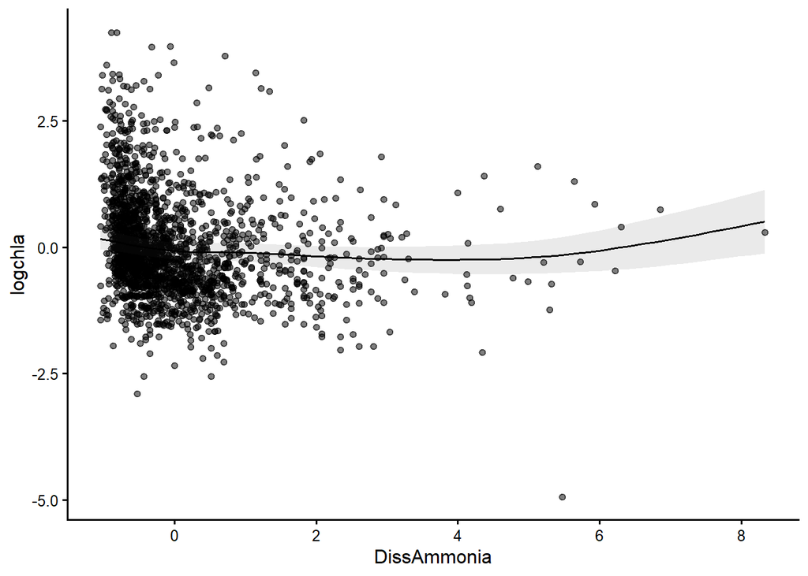

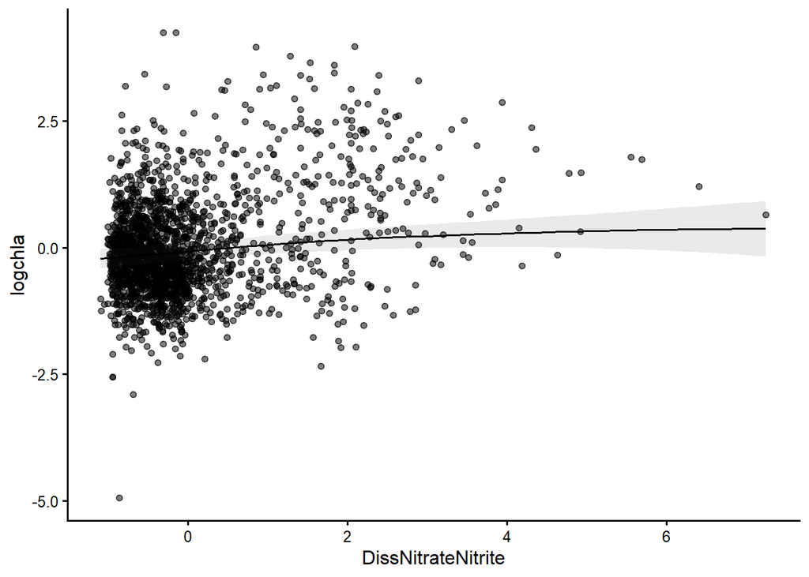

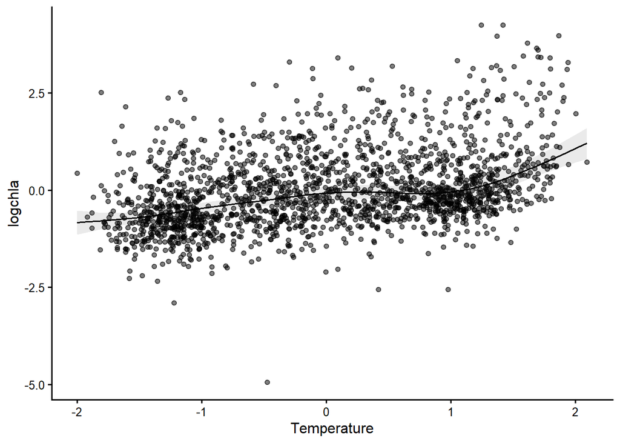

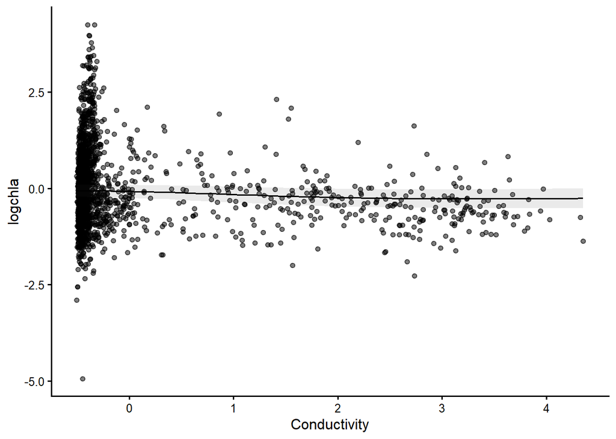

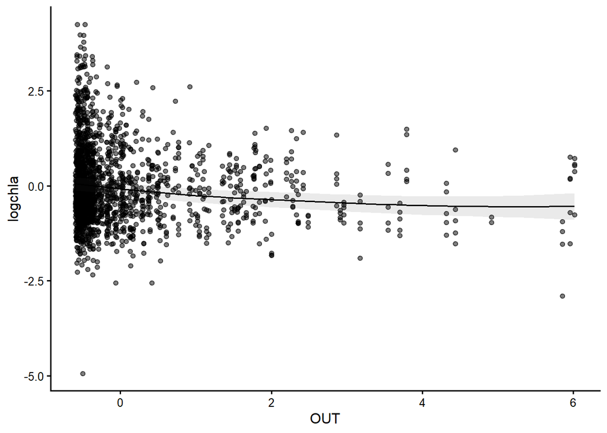

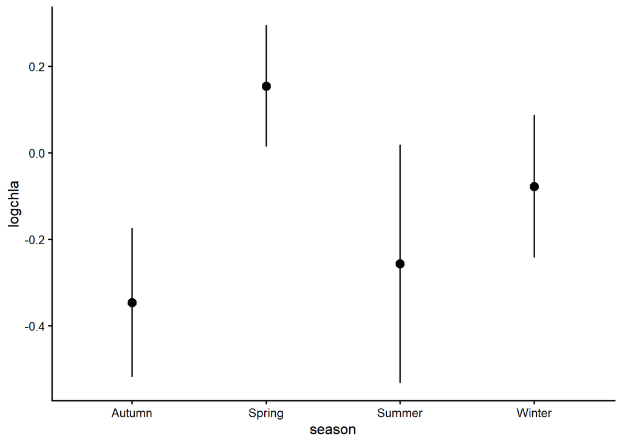

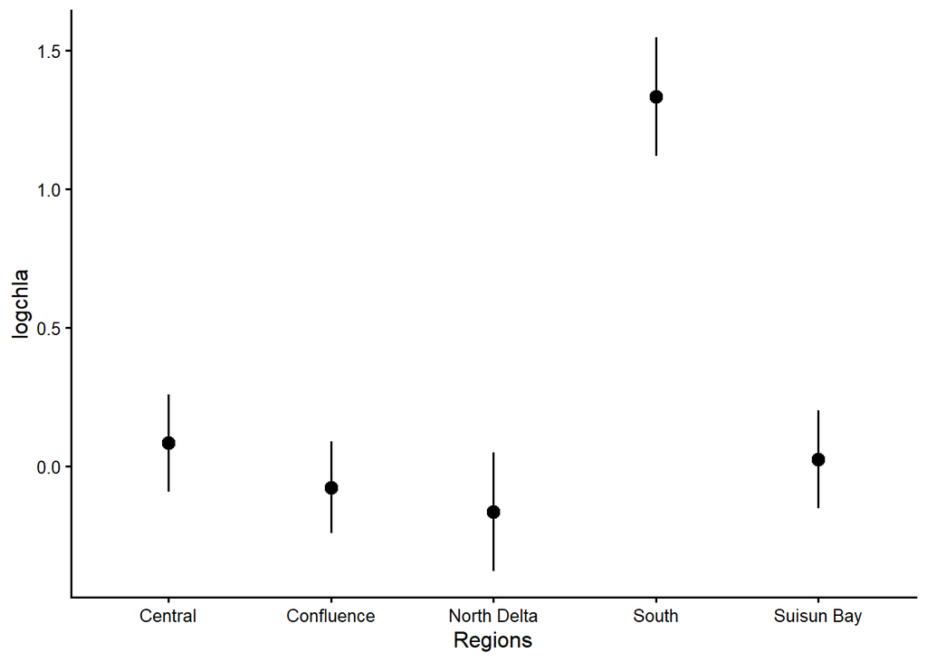

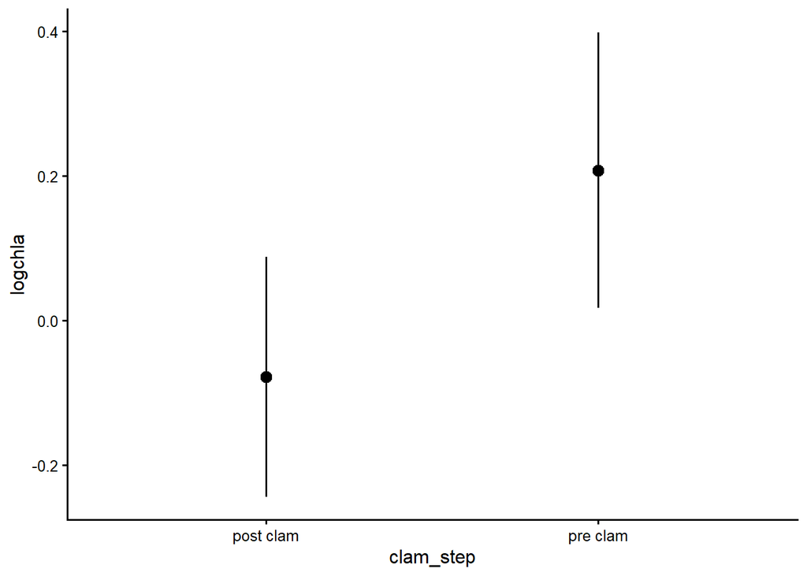

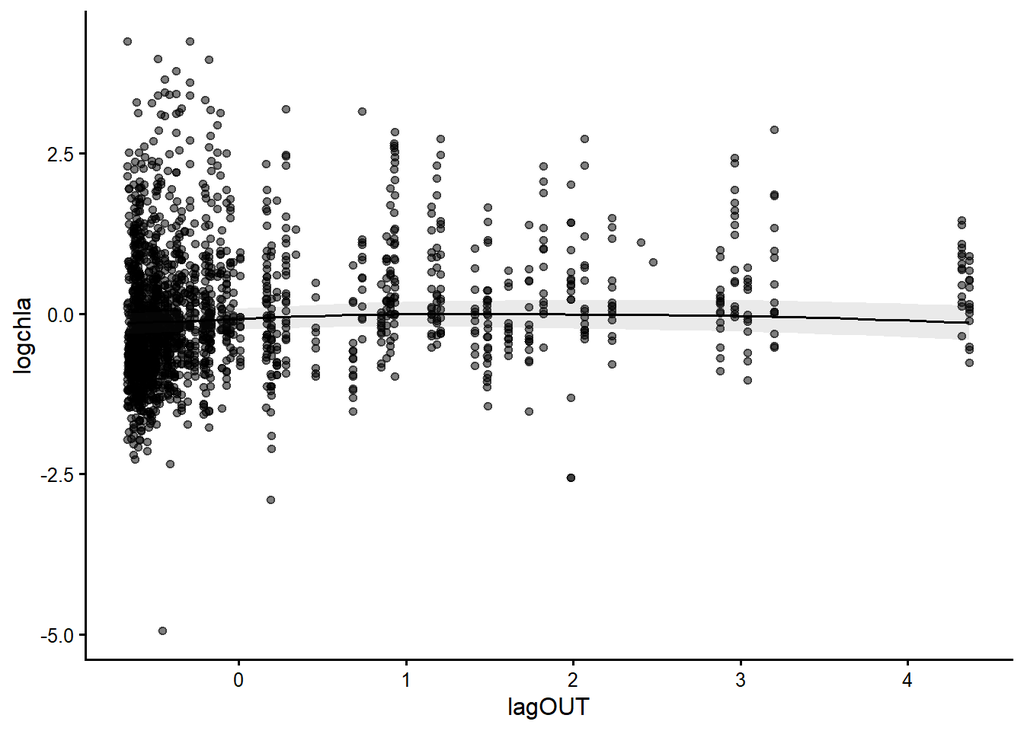

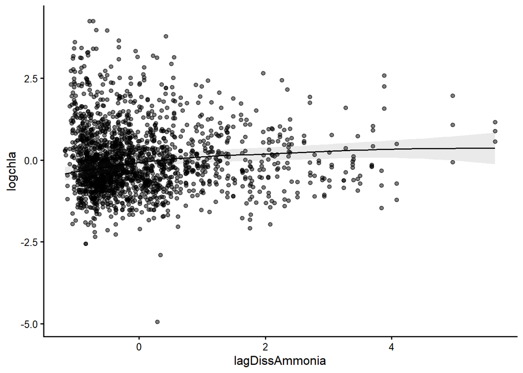

```r
# Plot data with model fit
c <- c("DissAmmonia",
          "DissNitrateNitrite",
          "Temperature",
          "Conductivity",
          "OUT",
          "season",
          "Regions",
          "clam_step",
          "lagOUT",
          "lagDissAmmonia")

lapply(c, function(x) {
  plot_predictions(top.m3.shrink, x , points = .5) +
    theme_classic(base_size = 12)
})
```

### Gam check

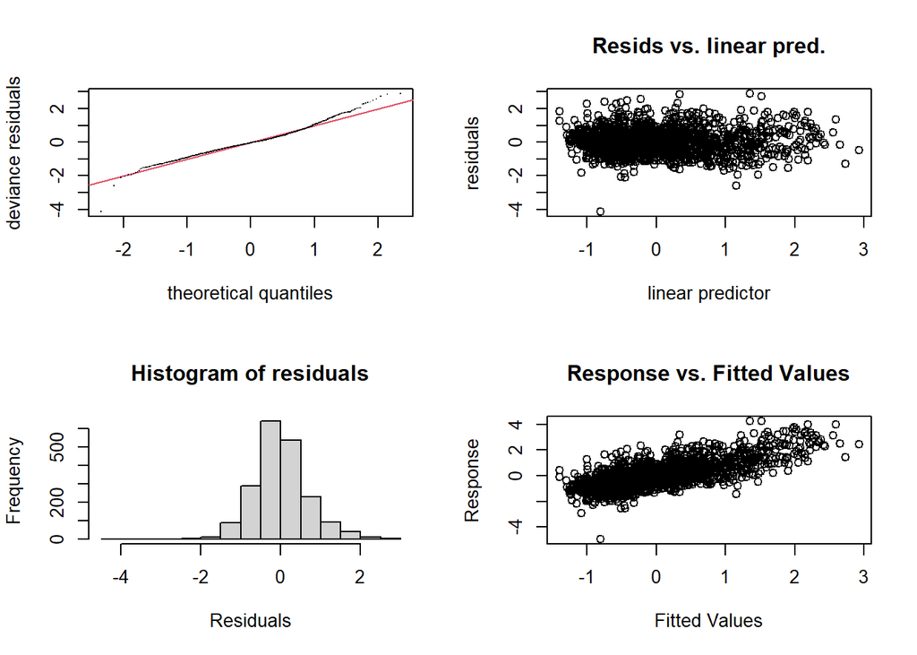

```
##
## Method: ML   Optimizer: outer newton
## full convergence after 15 iterations.
## Gradient range [-0.0004497173,0.0002711301]
## (score 2054.242 & scale 0.4592407).
## Hessian positive definite, eigenvalue range [0.000159905,974.0278].
## Model rank =  86 / 86
##
## Basis dimension (k) checking results. Low p-value (k-index<1) may
## indicate that k is too low, especially if edf is close to k'.
##
##                            k'  edf k-index p-value
## s(DissAmmonia)           9.00 3.67    1.00   0.340
## s(DissNitrateNitrite)    9.00 1.81    0.95   0.005 **
## s(Temperature)           9.00 6.00    0.99   0.365
## s(Conductivity)          9.00 1.51    1.01   0.625
## s(OUT)                   9.00 1.35    0.84  <2e-16 ***
## s(Regions)               5.00 3.95      NA      NA
## s(lagOUT)                9.00 1.84    0.76  <2e-16 ***
## s(lagDissAmmonia)        9.00 2.92    0.82  <2e-16 ***
## s(lagDissNitrateNitrite) 9.00 5.68    0.81  <2e-16 ***
## ---
## Signif. codes:  0 '***' 0.001 '**' 0.01 '*' 0.05 '.' 0.1 ' ' 1
```

```r
gam.check(top.m3.shrink)
```

## m4

### concurvity

<0.3 - low, >0.5 - some concern, >0.8 - very high

```r
concurvity(top.m4.shrink)
```

```
##          para s(DissAmmonia) s(DissNitrateNitrite) s(Temperature)
## worst       1      0.5512809             0.7914037      0.8333336
## observed    1      0.5201487             0.7616400      0.6766529
## estimate    1      0.2206387             0.3644935      0.7325139
##          s(Conductivity)    s(SAC) s(Regions) s(lagSAC) s(lagDissAmmonia)
## worst          0.8486841 1.0000000  1.0000000 0.7741480         0.5809557
## observed       0.3359727 0.3383297  0.6323293 0.5629565         0.5584264
## estimate       0.5504914 0.8608798  0.6632473 0.6905269         0.2878915
```

```r
concurvity(top.m4.shrink, full =FALSE)
```

```
## $worst
##                               para s(DissAmmonia) s(DissNitrateNitrite)
## para                  1.000000e+00   1.295191e-24          5.390176e-25
## s(DissAmmonia)        1.291447e-24   1.000000e+00          1.078337e-01
## s(DissNitrateNitrite) 5.442765e-25   1.078337e-01          1.000000e+00
## s(Temperature)        3.691599e-26   1.782065e-01          1.112880e-01
## s(Conductivity)       3.301724e-24   5.951166e-02          2.443357e-01
## s(SAC)                3.083636e-21   4.287940e-02          2.295608e-02
## s(Regions)            1.000000e+00   1.939357e-01          5.804513e-01
## s(lagSAC)             1.882065e-21   8.213604e-02          1.071834e-01
## s(lagDissAmmonia)     5.179086e-22   2.504284e-01          7.421004e-02
##                       s(Temperature) s(Conductivity)       s(SAC)  s(Regions)
## para                    3.729766e-26    3.307406e-24 3.083335e-21 1.000000000
## s(DissAmmonia)          1.782065e-01    5.951166e-02 4.287940e-02 0.193935681
## s(DissNitrateNitrite)   1.112880e-01    2.443357e-01 2.295608e-02 0.580451315
## s(Temperature)          1.000000e+00    6.616967e-02 1.837812e-01 0.115978931
## s(Conductivity)         6.616967e-02    1.000000e+00 1.809270e-01 0.751479908
## s(SAC)                  1.837812e-01    1.809270e-01 1.000000e+00 0.001043658
## s(Regions)              1.159789e-01    7.514799e-01 1.043658e-03 1.000000000
## s(lagSAC)               1.043595e-01    2.209808e-01 3.037401e-01 0.001340388
## s(lagDissAmmonia)       8.258159e-02    9.907485e-02 5.939215e-02 0.312066920
##                          s(lagSAC) s(lagDissAmmonia)
## para                  1.881520e-21      5.179709e-22
## s(DissAmmonia)        8.213604e-02      2.504284e-01
## s(DissNitrateNitrite) 1.071834e-01      7.421004e-02
## s(Temperature)        1.043595e-01      8.258159e-02
## s(Conductivity)       2.209808e-01      9.907485e-02
## s(SAC)                3.037401e-01      5.939215e-02
## s(Regions)            1.340388e-03      3.120669e-01
## s(lagSAC)             1.000000e+00      6.314754e-02
## s(lagDissAmmonia)     6.314754e-02      1.000000e+00
##
## $observed
##                               para s(DissAmmonia) s(DissNitrateNitrite)
## para                  1.000000e+00   1.430333e-30          2.123176e-29
## s(DissAmmonia)        1.291447e-24   1.000000e+00          2.308152e-02
## s(DissNitrateNitrite) 5.442765e-25   2.475294e-02          1.000000e+00
## s(Temperature)        3.691599e-26   1.458472e-01          7.768341e-02
## s(Conductivity)       3.301724e-24   3.724817e-03          2.108637e-01
## s(SAC)                3.083636e-21   3.377326e-02          1.155896e-02
```

[output cut: 40 more lines]

```
## s(Conductivity)         8.249880e-03    1.000000e+00 1.020234e-01 0.2074048713
## s(SAC)                  1.283241e-01    5.683317e-02 1.000000e+00 0.0002320061
## s(Regions)              1.420804e-02    4.364482e-01 7.780507e-05 1.0000000000
## s(lagSAC)               6.870376e-02    3.909476e-02 1.402098e-01 0.0003524903
## s(lagDissAmmonia)       4.819182e-02    4.515467e-02 2.454035e-02 0.0952022807
##                          s(lagSAC) s(lagDissAmmonia)
## para                  6.913607e-24      3.999123e-24
## s(DissAmmonia)        6.316510e-02      1.048345e-01
## s(DissNitrateNitrite) 8.300974e-02      1.797857e-02
## s(Temperature)        7.303713e-02      1.645600e-02
## s(Conductivity)       1.398172e-01      4.647874e-02
## s(SAC)                1.724790e-01      1.283933e-02
## s(Regions)            1.814256e-04      1.446990e-01
## s(lagSAC)             1.000000e+00      1.702272e-02
## s(lagDissAmmonia)     2.863222e-02      1.000000e+00
```

### VIF

```r
m.l<- lm(formula = logchla ~ SAC + clam_step,
            data=df)
vif(m.l)
```

```
##       SAC clam_step
##  1.057444  1.057444
```

### Marginal Effects

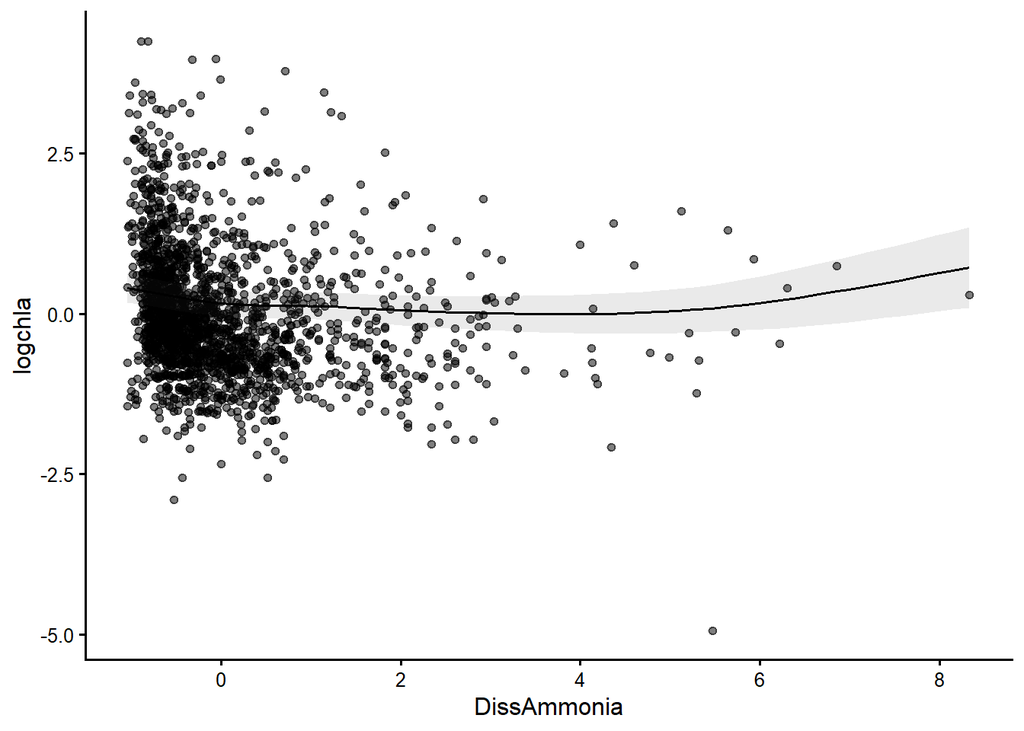

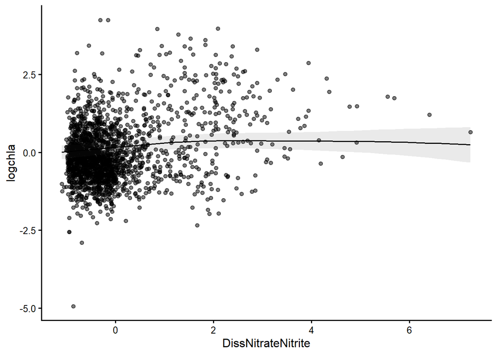

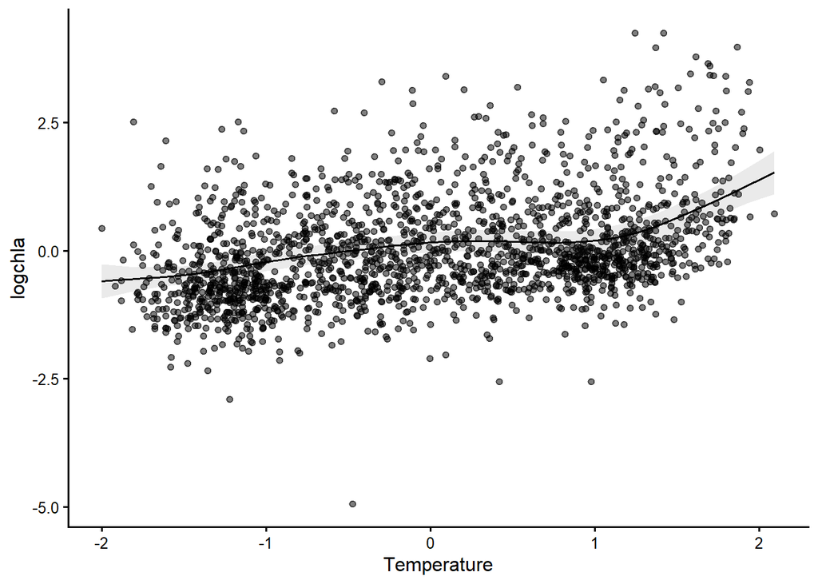

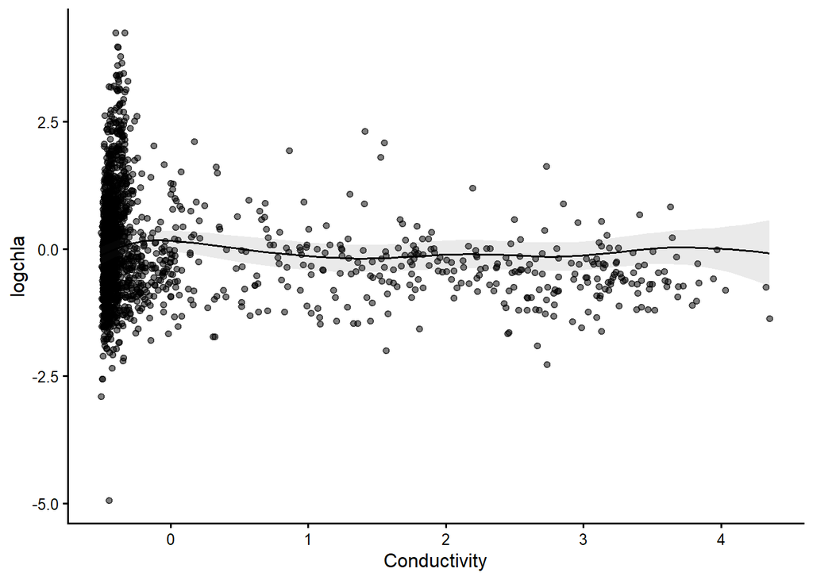

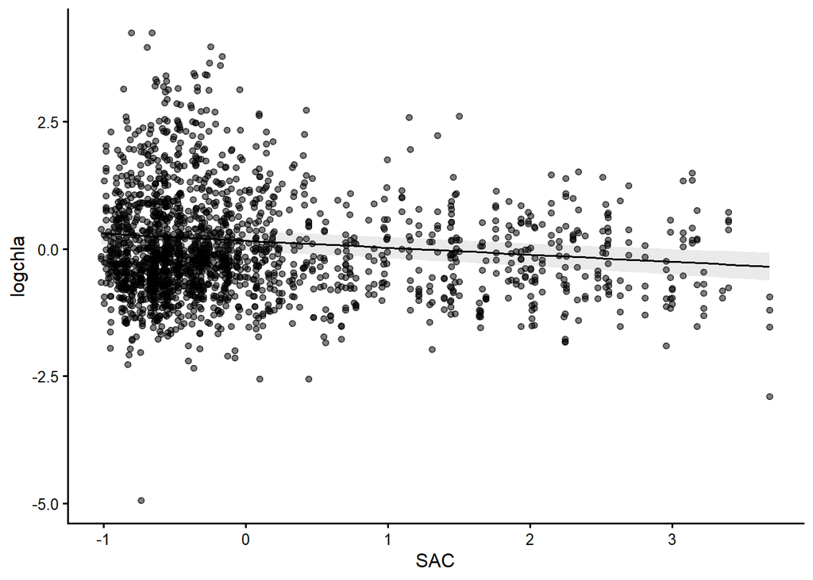

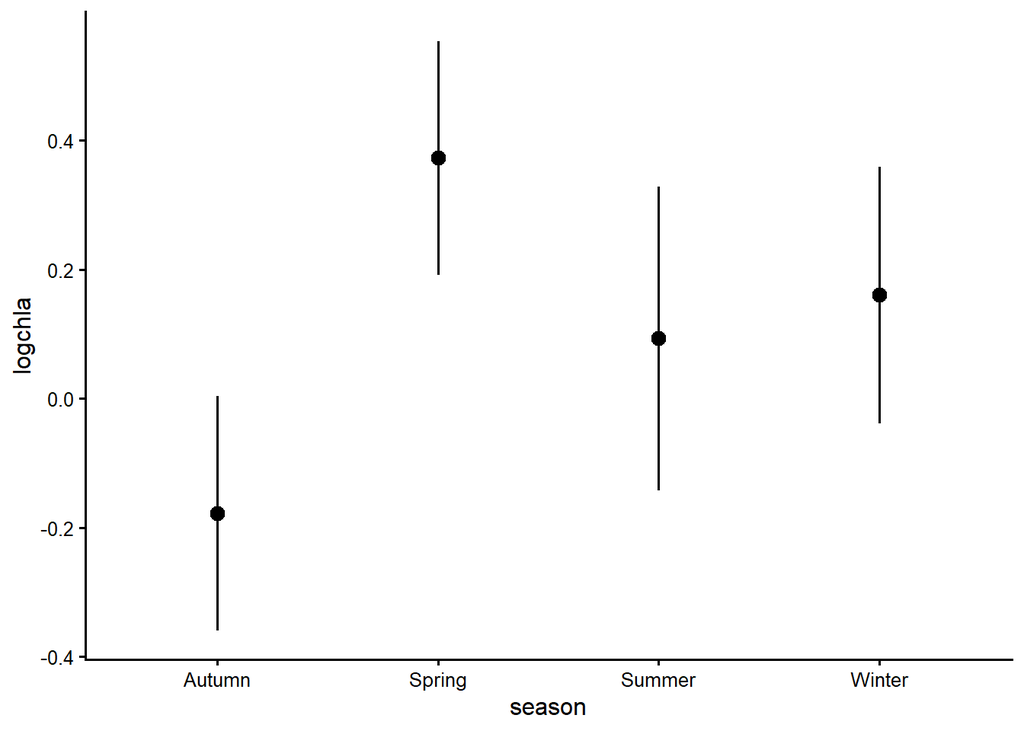

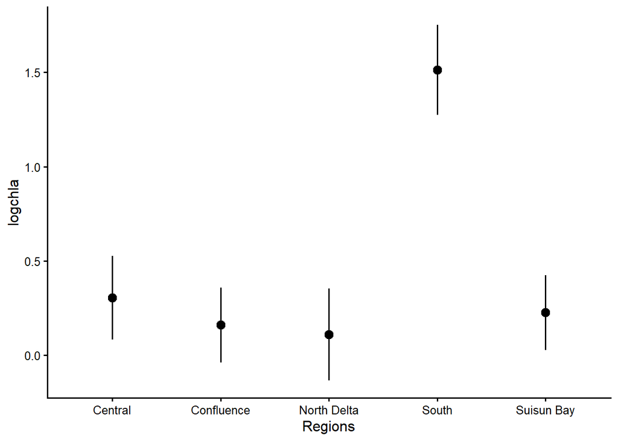

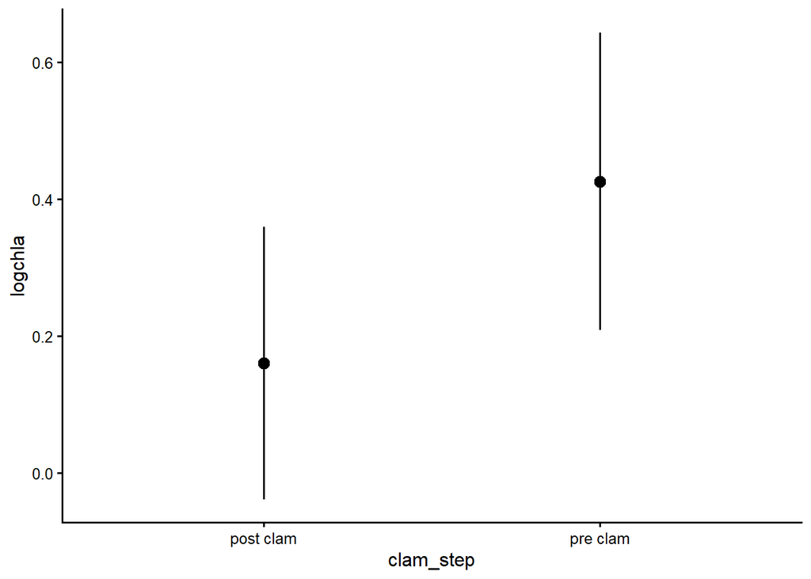

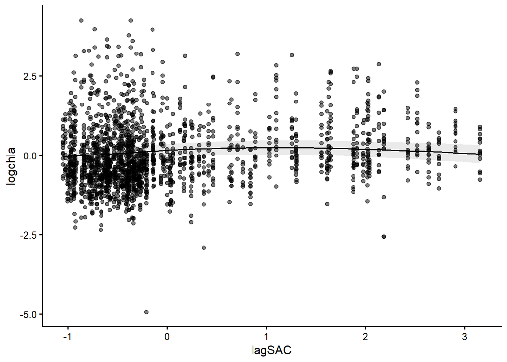

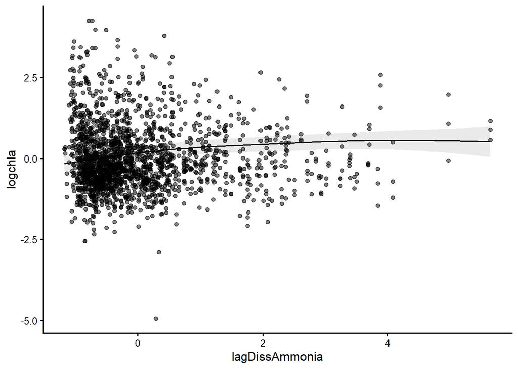

```r
# Plot data with model fit
c <- c("DissAmmonia",
          "DissNitrateNitrite",
          "Temperature",
          "Conductivity",
          "SAC",
          "season",
          "Regions",
          "clam_step",
          "lagSAC",
          "lagDissAmmonia")

lapply(c, function(x) {
  plot_predictions(top.m4.shrink, x , points = .5) +
    theme_classic(base_size = 12)
})
```

### Gam check

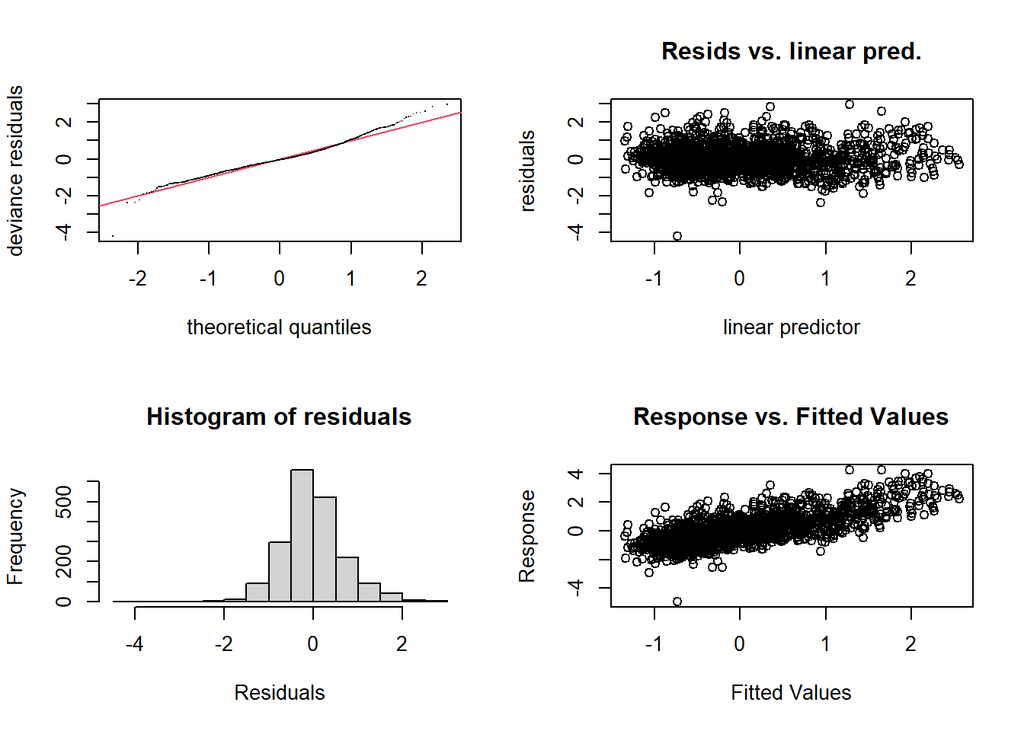

```
##
## Method: ML   Optimizer: outer newton
## full convergence after 17 iterations.
## Gradient range [-4.322287e-05,0.0002127224]
## (score 2050.635 & scale 0.4583095).
## Hessian positive definite, eigenvalue range [3.08284e-05,974.0279].
## Model rank =  77 / 77
##
## Basis dimension (k) checking results. Low p-value (k-index<1) may
## indicate that k is too low, especially if edf is close to k'.
##
##                             k'      edf k-index p-value
## s(DissAmmonia)        9.00e+00 3.55e+00    0.99   0.360
## s(DissNitrateNitrite) 9.00e+00 2.32e+00    0.95   0.005 **
## s(Temperature)        9.00e+00 6.12e+00    1.00   0.465
## s(Conductivity)       9.00e+00 6.03e+00    1.01   0.685
## s(SAC)                9.00e+00 9.81e-05    0.87  <2e-16 ***
## s(Regions)            5.00e+00 3.95e+00      NA      NA
## s(lagSAC)             9.00e+00 2.39e+00    0.76  <2e-16 ***
## s(lagDissAmmonia)     9.00e+00 2.83e+00    0.82  <2e-16 ***
## ---
## Signif. codes:  0 '***' 0.001 '**' 0.01 '*' 0.05 '.' 0.1 ' ' 1
```

```r
gam.check(top.m4.shrink)
```

## m6

### concurvity

<0.3 - low, >0.5 - some concern, >0.8 - very high

```r
concurvity(m6.shrink)
```

```
##          para s(DissAmmonia) s(DissNitrateNitrite) s(Temperature)
## worst       1      0.5539239             0.7925992      0.8259221
## observed    1      0.5231963             0.7551490      0.6633582
## estimate    1      0.2230290             0.3671843      0.7263039
##          s(Conductivity)    s(SAC) s(EXPORT) s(Regions) s(lagSAC)
## worst          0.8486339 0.7176448 0.6710931  1.0000000 0.7043151
## observed       0.3436972 0.6028547 0.5515829  0.6450462 0.6421268
## estimate       0.5488304 0.4891093 0.5892369  0.6633960 0.5910865
##          s(lagDissAmmonia)
## worst            0.5821210
## observed         0.5572707
## estimate         0.2913569
```

```r
concurvity(m6.shrink, full =FALSE)
```

```
## $worst
##                               para s(DissAmmonia) s(DissNitrateNitrite)
## para                  1.000000e+00   1.295191e-24          5.390176e-25
## s(DissAmmonia)        1.288040e-24   1.000000e+00          1.078337e-01
## s(DissNitrateNitrite) 5.402555e-25   1.078337e-01          1.000000e+00
## s(Temperature)        3.696545e-26   1.782065e-01          1.112880e-01
## s(Conductivity)       3.329749e-24   5.951166e-02          2.443357e-01
## s(SAC)                3.083559e-21   4.287940e-02          2.295608e-02
## s(EXPORT)             6.501911e-26   5.306032e-02          2.018001e-02
## s(Regions)            1.000000e+00   1.939357e-01          5.804513e-01
## s(lagSAC)             1.881455e-21   8.213604e-02          1.071834e-01
## s(lagDissAmmonia)     5.181181e-22   2.504284e-01          7.421004e-02
##                       s(Temperature) s(Conductivity)       s(SAC)    s(EXPORT)
## para                    3.729766e-26    3.307406e-24 3.083335e-21 6.512906e-26
## s(DissAmmonia)          1.782065e-01    5.951166e-02 4.287940e-02 5.306032e-02
## s(DissNitrateNitrite)   1.112880e-01    2.443357e-01 2.295608e-02 2.018001e-02
## s(Temperature)          1.000000e+00    6.616967e-02 1.837812e-01 1.511720e-01
## s(Conductivity)         6.616967e-02    1.000000e+00 1.809270e-01 4.631738e-02
## s(SAC)                  1.837812e-01    1.809270e-01 1.000000e+00 4.585943e-01
## s(EXPORT)               1.511720e-01    4.631738e-02 4.585943e-01 1.000000e+00
## s(Regions)              1.159789e-01    7.514799e-01 1.043658e-03 4.369063e-03
## s(lagSAC)               1.043595e-01    2.209808e-01 3.037401e-01 1.940700e-01
## s(lagDissAmmonia)       8.258159e-02    9.907485e-02 5.939215e-02 3.046769e-02
##                        s(Regions)    s(lagSAC) s(lagDissAmmonia)
## para                  1.000000000 1.881520e-21      5.179709e-22
## s(DissAmmonia)        0.193935681 8.213604e-02      2.504284e-01
## s(DissNitrateNitrite) 0.580451315 1.071834e-01      7.421004e-02
## s(Temperature)        0.115978931 1.043595e-01      8.258159e-02
## s(Conductivity)       0.751479908 2.209808e-01      9.907485e-02
## s(SAC)                0.001043658 3.037401e-01      5.939215e-02
## s(EXPORT)             0.004369063 1.940700e-01      3.046769e-02
## s(Regions)            1.000000000 1.340388e-03      3.120669e-01
## s(lagSAC)             0.001340388 1.000000e+00      6.314754e-02
## s(lagDissAmmonia)     0.312066920 6.314754e-02      1.000000e+00
##
## $observed
##                               para s(DissAmmonia) s(DissNitrateNitrite)
## para                  1.000000e+00   4.930013e-31          4.040173e-29
## s(DissAmmonia)        1.288040e-24   1.000000e+00          2.479087e-02
## s(DissNitrateNitrite) 5.402555e-25   2.538012e-02          1.000000e+00
```

[output cut: 49 more lines]

```
## s(EXPORT)               7.540753e-02    1.095574e-02 3.328935e-02 1.000000e+00
## s(Regions)              1.420804e-02    4.364482e-01 7.780507e-05 1.626464e-03
## s(lagSAC)               6.870376e-02    3.909476e-02 1.402098e-01 1.298538e-01
## s(lagDissAmmonia)       4.819182e-02    4.515467e-02 2.454035e-02 2.150237e-02
##                         s(Regions)    s(lagSAC) s(lagDissAmmonia)
## para                  0.2041819336 6.913607e-24      3.999123e-24
## s(DissAmmonia)        0.0659385172 6.316510e-02      1.048345e-01
## s(DissNitrateNitrite) 0.2013013116 8.300974e-02      1.797857e-02
## s(Temperature)        0.0306083025 7.303713e-02      1.645600e-02
## s(Conductivity)       0.2074048713 1.398172e-01      4.647874e-02
## s(SAC)                0.0002320061 1.724790e-01      1.283933e-02
## s(EXPORT)             0.0007508673 5.580622e-02      5.584554e-03
## s(Regions)            1.0000000000 1.814256e-04      1.446990e-01
## s(lagSAC)             0.0003524903 1.000000e+00      1.702272e-02
## s(lagDissAmmonia)     0.0952022807 2.863222e-02      1.000000e+00
```

### VIF

```r
m.l<- lm(formula = logchla ~ SAC+ EXPORT + clam_step,
            data=df)
vif(m.l)
```

```
##       SAC    EXPORT clam_step
##  1.074422  1.019909  1.065990
```